EXPLORATORY DATA ANALYSIS ON MEDICAL COST PERSONAL DATASET

**Data Description**

#### *This dataset explains the cost of a small sample of USA population Medical Insurance Cost based on some attributes such as age, sex, bmi etc.This dataset corresponds to a practical used in the book Machine Learning with R by Brett Lantz; which is a book that provides an introduction to machine learning using R. All of these datasets are in the public domain but simply needed some cleaning up and recoding to match the format in the book.*

**Columns**

#### **Age**: *Age of primary beneficiary*

#### **Sex**: *Insurance contractor gender, female, male*

#### **BMI**: *Body mass index, providing an understanding of body, weights that are relatively high or low relative to height, objective index of body weight (kg / m ^ 2) using the ratio of height to weight, ideally 18.5 to 24.9*

#### **Children**: *Number of children covered by health insurance / Number of dependents*

#### **Smoker**: *Smoking*

#### **Region**: *The beneficiary’s residential area in the US, northeast, southeast, southwest, northwest.*

#### **Charges**: *Individual medical costs billed by health insurance*

**R Packages**

```r
library(readr)              #read in the data
library(ggplot2)            #visualization
library(corrplot)           #visualization of correlation
library(tidyverse)          #used for data transformations
library(gridExtra)          #used for extension to a grid system
```

**Reading and Understanding data**

```r
insurance_data=read.csv("C:\\Users\\Shruti Saraf\\OneDrive\\Desktop\\Project\\Medical Cost Personal Datasets.csv")

View(insurance_data)

glimpse(insurance_data)
```

```
## Rows: 1,338
## Columns: 7
## $ age      <int> 19, 18, 28, 33, 32, 31, 46, 37, 37, 60, 25, 62, 23, 56, 27, 1…
## $ sex      <chr> "female", "male", "male", "male", "male", "female", "female",…
## $ bmi      <dbl> 27.900, 33.770, 33.000, 22.705, 28.880, 25.740, 33.440, 27.74…
## $ children <int> 0, 1, 3, 0, 0, 0, 1, 3, 2, 0, 0, 0, 0, 0, 0, 1, 1, 0, 0, 0, 0…
## $ smoker   <chr> "yes", "no", "no", "no", "no", "no", "no", "no", "no", "no", …
## $ region   <chr> "southwest", "southeast", "southeast", "northwest", "northwes…
## $ charges  <dbl> 16884.924, 1725.552, 4449.462, 21984.471, 3866.855, 3756.622,…
```

```r
str(insurance_data)
```

```
## 'data.frame':    1338 obs. of  7 variables:
##  $ age     : int  19 18 28 33 32 31 46 37 37 60 ...
##  $ sex     : chr  "female" "male" "male" "male" ...
##  $ bmi     : num  27.9 33.8 33 22.7 28.9 ...
##  $ children: int  0 1 3 0 0 0 1 3 2 0 ...
##  $ smoker  : chr  "yes" "no" "no" "no" ...
##  $ region  : chr  "southwest" "southeast" "southeast" "northwest" ...
##  $ charges : num  16885 1726 4449 21984 3867 ...
```

```r
summary(insurance_data)
```

```
##       age            sex                 bmi           children
##  Min.   :18.00   Length:1338        Min.   :15.96   Min.   :0.000
##  1st Qu.:27.00   Class :character   1st Qu.:26.30   1st Qu.:0.000
##  Median :39.00   Mode  :character   Median :30.40   Median :1.000
##  Mean   :39.21                      Mean   :30.66   Mean   :1.095
##  3rd Qu.:51.00                      3rd Qu.:34.69   3rd Qu.:2.000
##  Max.   :64.00                      Max.   :53.13   Max.   :5.000
##     smoker             region             charges
##  Length:1338        Length:1338        Min.   : 1122
##  Class :character   Class :character   1st Qu.: 4740
##  Mode  :character   Mode  :character   Median : 9382
##                                        Mean   :13270
##                                        3rd Qu.:16640
##                                        Max.   :63770
```

##### **Interpretation**:- The respondents’ gender and region of origin is evenly distributed, having age ranging from 18 to 64 years old. Non-smokers outnumber smokers 4 to 1. The average, medical cost is USD 13,270 with a median value of USD 9382.

**Exploratory Data Analysis (EDA)**

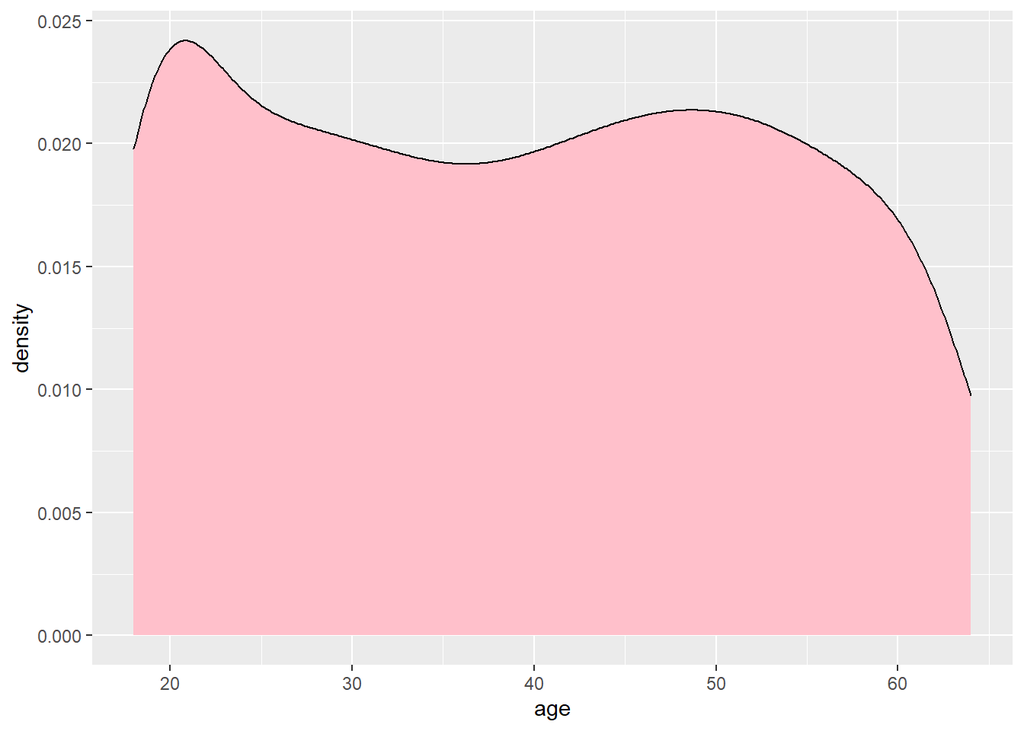

```r
ggplot(data = insurance_data , mapping = aes(x = age))+
  geom_density(color = "black",fill="pink")
```

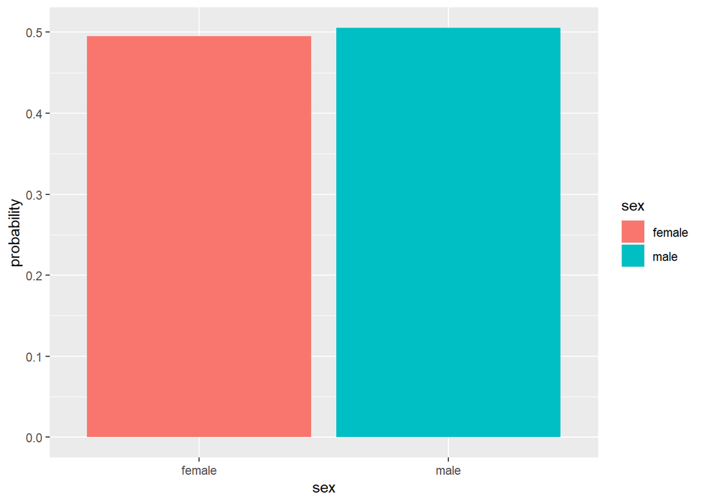

```r
ggplot(data = insurance_data , mapping = aes(x = sex,y=(..count../sum(..count..)),fill=sex))+
  geom_bar()+labs(x="sex",y="probability")
```

##### **Interpretation**:- Male - 50.52% and Female - 49.48%

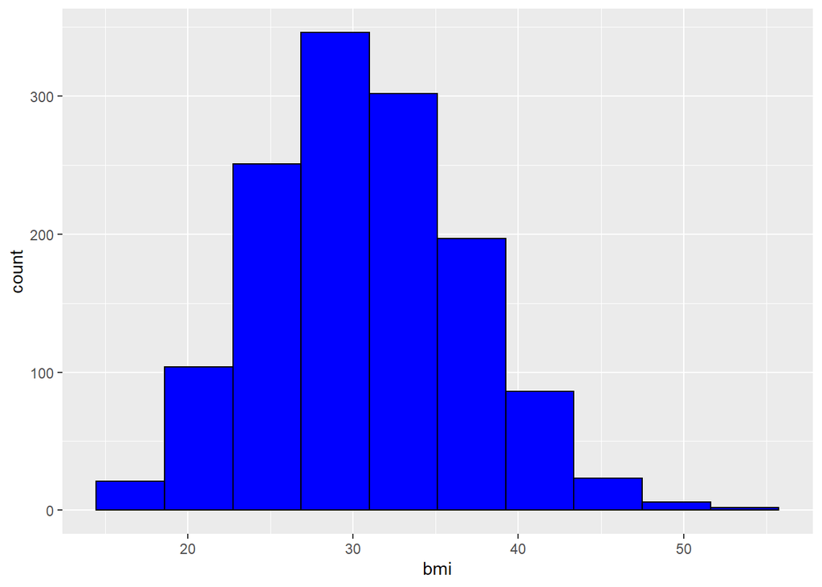

```r
ggplot(data = insurance_data , mapping = aes(x = bmi))+
  geom_histogram(color = "black",fill="Blue",bins=10 )
```

##### **Interpretation**:- Mostly the BMI is 30.

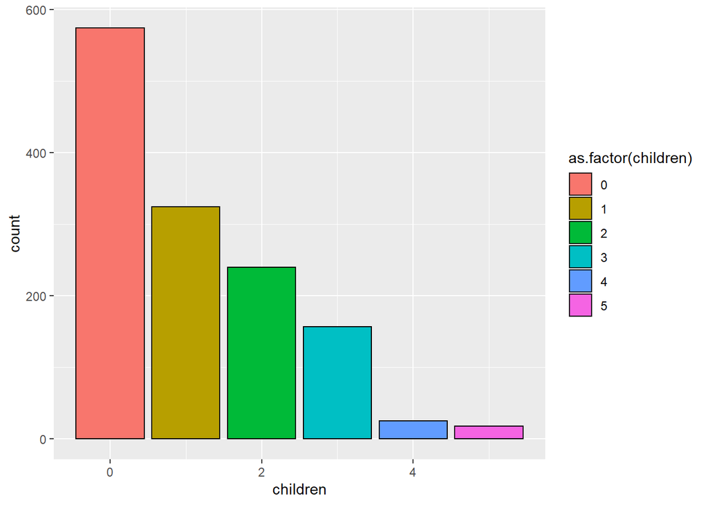

```r
ggplot(data = insurance_data , mapping = aes(x = children,fill=as.factor(children)))+
  geom_bar(  color = "black")
```

##### **Interpretation**:- Maximum people does not have any child.

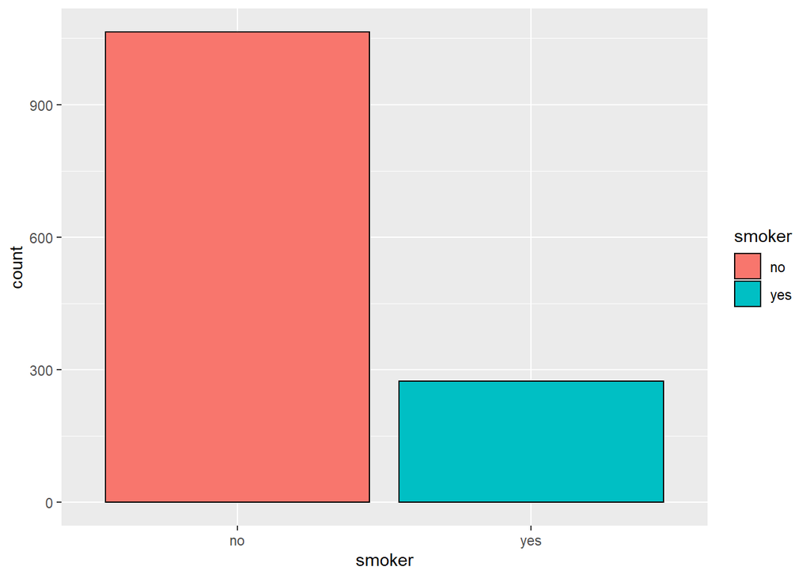

```r
ggplot(data = insurance_data , mapping = aes(x = smoker,fill=smoker))+
  geom_bar(  color = "black")
```

##### **Interpretation**:- 20.48% are smokers

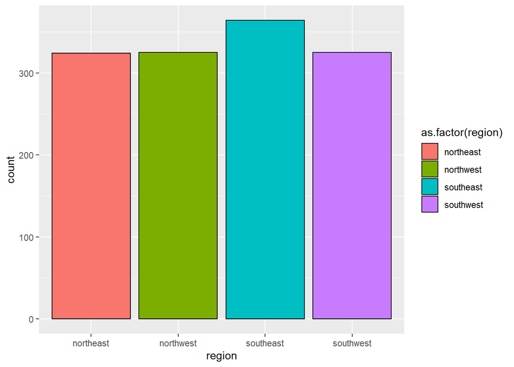

```r
ggplot(data = insurance_data , mapping = aes(x = region,fill=as.factor(region)))+
  geom_bar(color = "black")
```

##### **Interpretation**:- People mostly belong from southeast side.

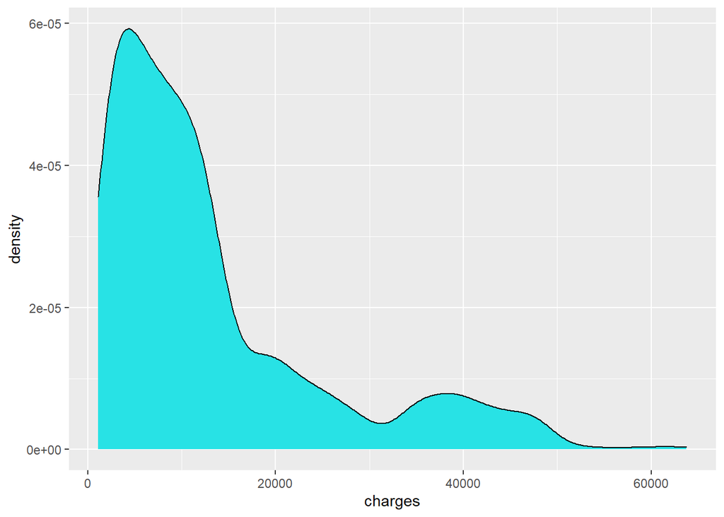

```r
ggplot(data = insurance_data , mapping = aes(x = charges))+
  geom_density(fill = 69)
```

##### **INRERPRETATION**:- Maximum people pays charges upto 20,000

**Correlation Plot**

```r
insurance_data1=insurance_data
insurance_data1$sex=as.numeric(factor(insurance_data1$sex,levels = c("female","male"),labels = c(0,1)))
insurance_data1$smoker=as.numeric(factor(insurance_data1$smoker,levels = c("no","yes"),labels = c(0,1)))
insurance_data1$region=as.numeric(factor(insurance_data1$region,levels = c("southwest","southeast","northwest","northeast"),labels = c(0,1,2,3)))
str(insurance_data1)
```

```
## 'data.frame':    1338 obs. of  7 variables:
##  $ age     : int  19 18 28 33 32 31 46 37 37 60 ...
##  $ sex     : num  1 2 2 2 2 1 1 1 2 1 ...
##  $ bmi     : num  27.9 33.8 33 22.7 28.9 ...
##  $ children: int  0 1 3 0 0 0 1 3 2 0 ...
##  $ smoker  : num  2 1 1 1 1 1 1 1 1 1 ...
##  $ region  : num  1 2 2 3 3 2 2 3 4 3 ...
##  $ charges : num  16885 1726 4449 21984 3867 ...
```

```r
corr_mtx=round(cor(insurance_data1),1)
corr_mtx
```

```
##          age sex  bmi children smoker region charges
## age      1.0 0.0  0.1      0.0    0.0    0.0     0.3
## sex      0.0 1.0  0.0      0.0    0.1    0.0     0.1
## bmi      0.1 0.0  1.0      0.0    0.0   -0.2     0.2
## children 0.0 0.0  0.0      1.0    0.0    0.0     0.1
## smoker   0.0 0.1  0.0      0.0    1.0    0.0     0.8
## region   0.0 0.0 -0.2      0.0    0.0    1.0     0.0
## charges  0.3 0.1  0.2      0.1    0.8    0.0     1.0
```

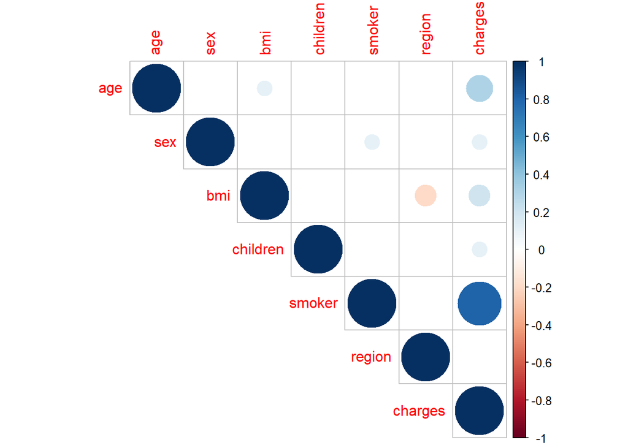

```r
corrplot(corr_mtx,method = "circle",type = "upper")
```

##### **Interpretation**:- As Smokers and charges are strongly correlated with charges, age is also correlated with charges followed by bmi,sex and children.

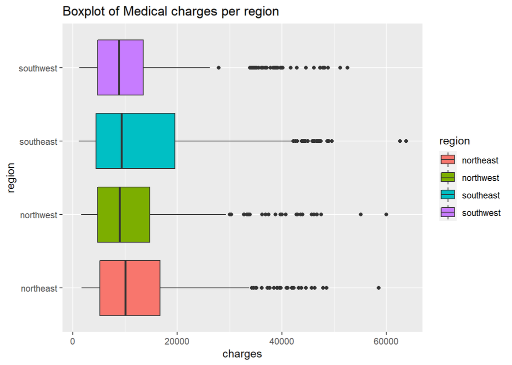

```r
ggplot(data = insurance_data , mapping = aes(x = region , y = charges , fill = region))+
  geom_boxplot()+
  theme_gray()+
  ggtitle("Boxplot of Medical charges per region")+
  coord_flip()
```

##### **Interpretation**:- Region doesn’t have much impact on the medical cost.

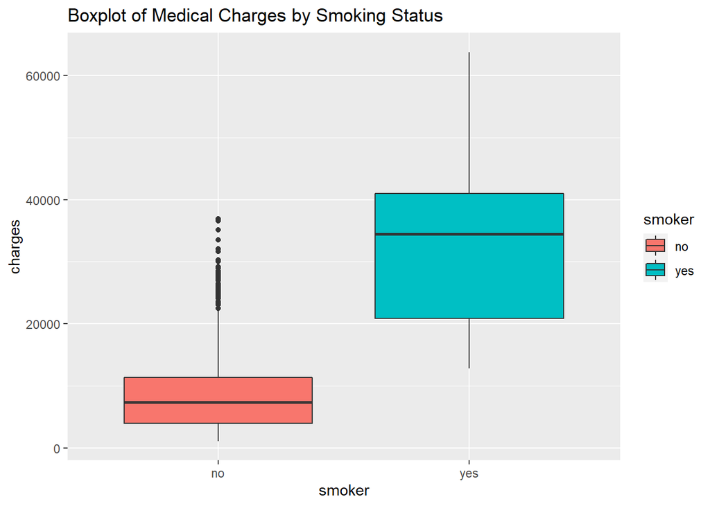

```r
ggplot(data = insurance_data , mapping = aes(x = smoker , y = charges , fill = smoker))+
  geom_boxplot()+
  theme_gray()+
  ggtitle("Boxplot of Medical Charges by Smoking Status")
```

##### **Interpretation**:- Smokers spends a lot more in terms of medical expenses compared to non-smokers by almost 4x.

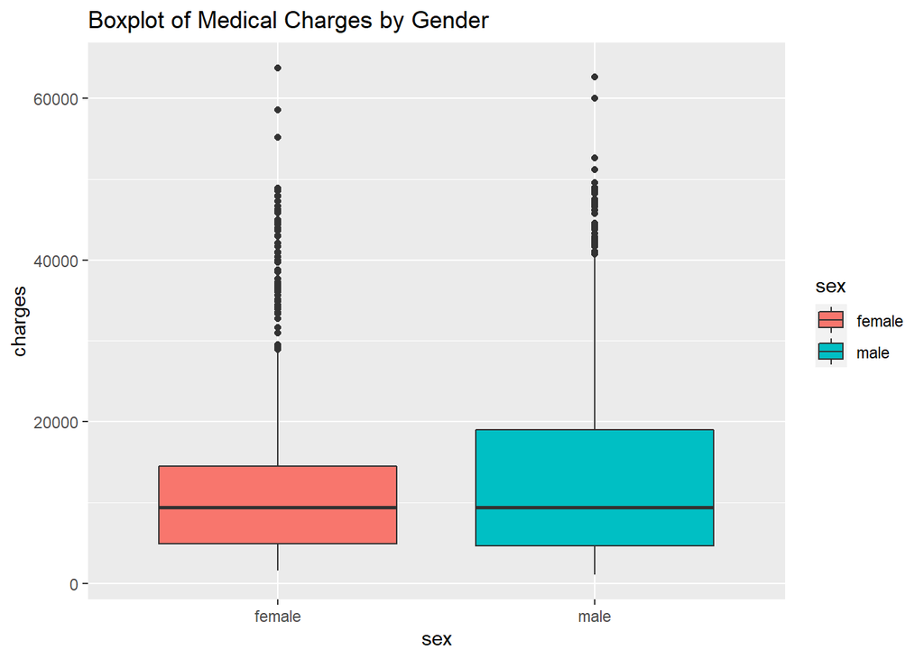

```r
ggplot(data = insurance_data , mapping = aes(x = sex , y = charges , fill = sex))+
  geom_boxplot()+
  theme_gray()+
  ggtitle("Boxplot of Medical Charges by Gender")
```

##### **Interpretation**:- The Sex of the policy holder has no significant effect on Charges. This corresponds to the previous boxplots, which showed that Male and Female policy holders have very similar mean Charges.

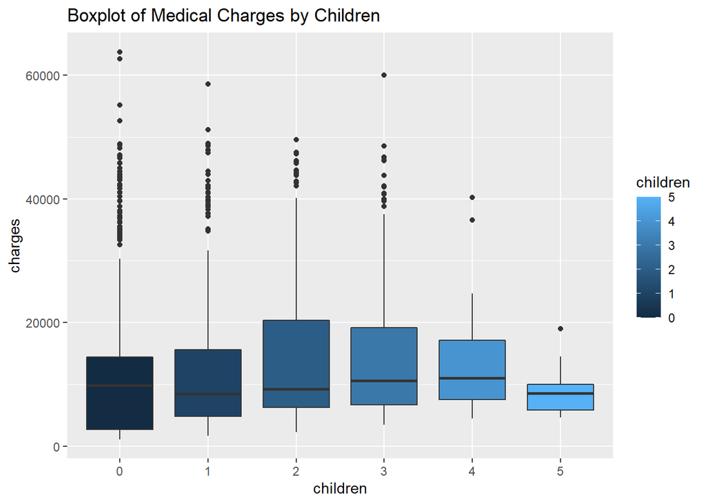

```r
ggplot(data = insurance_data , mapping = aes(x = as.factor(children) , y = charges , fill = children))+
  geom_boxplot()+
  theme_gray()+
  labs(x="children")+
  ggtitle("Boxplot of Medical Charges by Children")
```

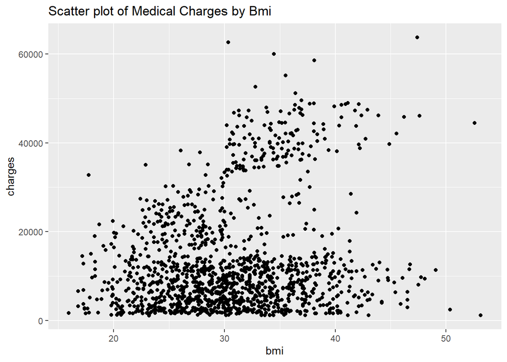

```r
ggplot(data = insurance_data , mapping = aes(x = bmi , y = charges))+
  geom_point()+
  theme_gray()+
  ggtitle("Scatter plot of Medical Charges by Bmi")
```

##### **Interpretation**:- Based on above plot, Bmi increases, charges increases

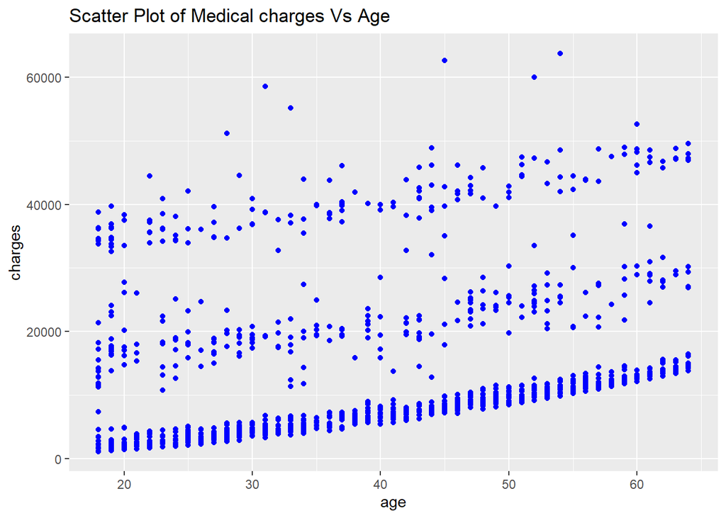

```r
ggplot(data=insurance_data,mapping=aes(x=age,y=charges))+
  geom_point(color = "blue")+
  ggtitle("Scatter Plot of Medical charges Vs Age")
```

##### **Interpretation**:- Charges increases as Age goes up.

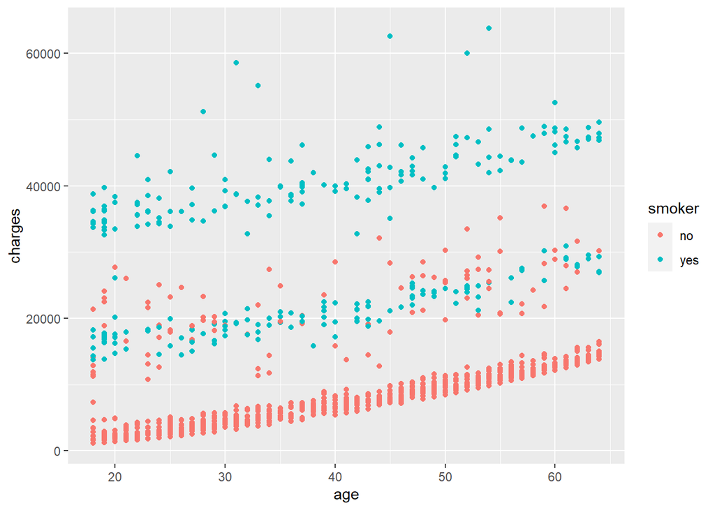

```r
ggplot(data = insurance_data , mapping = aes(x = age , y = charges , color = smoker))+
  geom_point(size = 1.5)+
  theme_gray()
```

##### **Interpretation**:- Smokers with increase in age has higher charges as compare to non-smokers with increase in age.

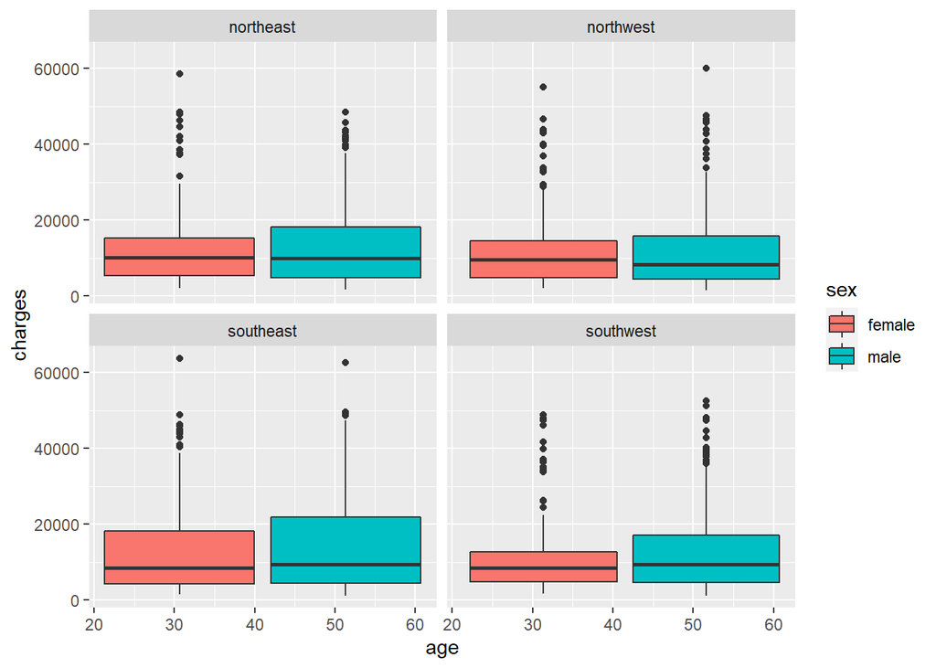

```r
ggplot(data = insurance_data , mapping = aes(x = age , y = charges , fill = sex))+
  geom_boxplot()+
  theme_gray()+
  facet_wrap(~region)
```

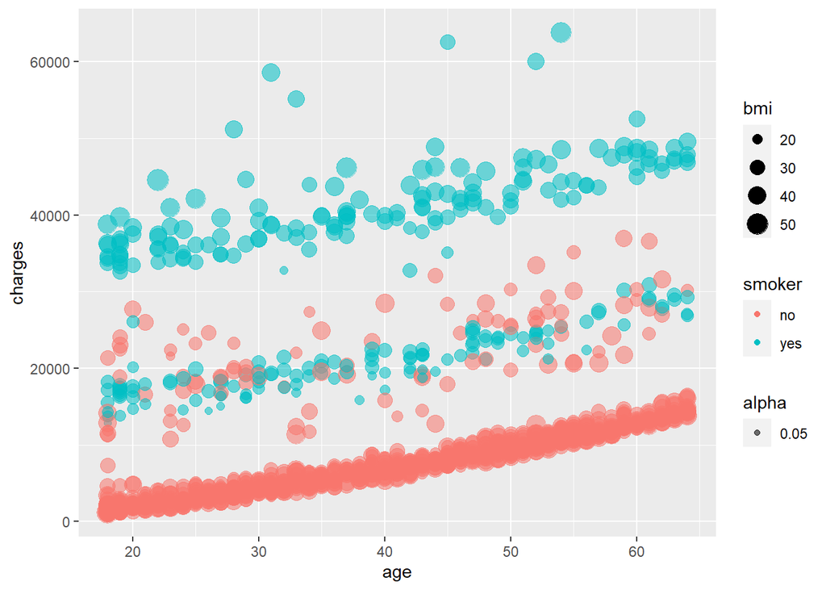

```r
ggplot(data = insurance_data , aes(x = age , y = charges))+
  geom_point(aes(color = smoker , size = bmi , alpha = 0.05))
```

##### **Interpretation**:- Smokers with increase in age who have higher bim have to pay more charges.

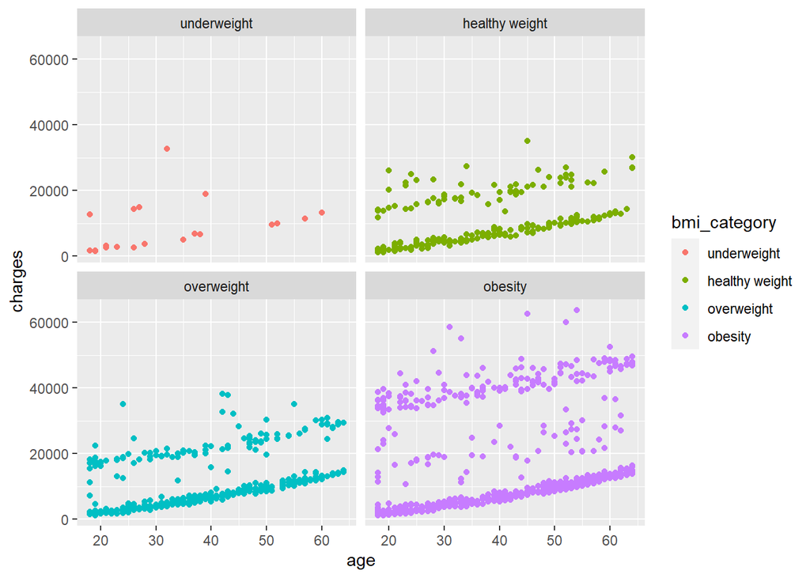

```r
insurance_data <- insurance_data %>%
  mutate(bmi_category = case_when(
    bmi < 18.5 ~ "underweight",
    bmi < 25 ~ "healthy weight",
    bmi < 30 ~ "overweight",
    bmi >= 30 ~ "obesity"
  ))
insurance_data$bmi_category = factor(insurance_data$bmi_category,
                    levels = c("underweight",
                               "healthy weight",
                               "overweight",
                               "obesity"))
ggplot(insurance_data, aes(x = age, y = charges, color = bmi_category)) +
  geom_point() +
  facet_wrap(~bmi_category)
```

##### **Interpretation**:- With increase in age, people who have more bmi have to pay more charges compared to others.

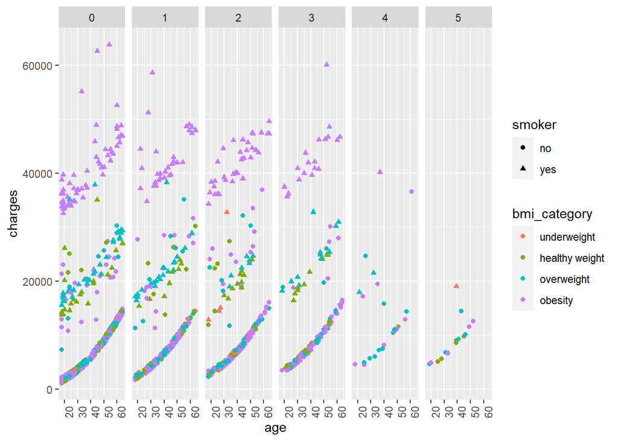

```r
ggplot(insurance_data, aes(x = age, y = charges, color = bmi_category,shape = smoker)) +
  geom_point()+
  facet_grid(~children)+
  theme(axis.text.x = element_text(angle = 90))
```

##### **Interpretation**:- Policy holders with 4 and 5 children having very less smokers with less charges with all categories for bmi.Policy holders with no child having smokers with more bmi has to pay more charges

[figure not shown]

```r
p1=ggplot(data = insurance_data , mapping = aes(x = bmi , y = charges , color = smoker ))+
  geom_point(size =1.5)+
  theme_gray()

p2=ggplot(insurance_data,aes(x=bmi_category,y=charges,fill=smoker))+
  geom_col(position = "dodge")+scale_x_discrete(labels = c("healthy weight","obesity","overweight","underweight"))+
  theme(axis.text.x = element_text(angle = 45,hjust = 1,size=10))

grid.arrange(p1,p2,nrow=1,ncol=2)
```

**EDA Conclusion**

#### • Region, sex, and having dependents on plan isn’t a factor that increases charges.

#### • Policy Holders with no child have impact on charges than policy holders with 5 children.